# St. Joseph Bay Aquatic Preserve

**Sampling locations by Program:**

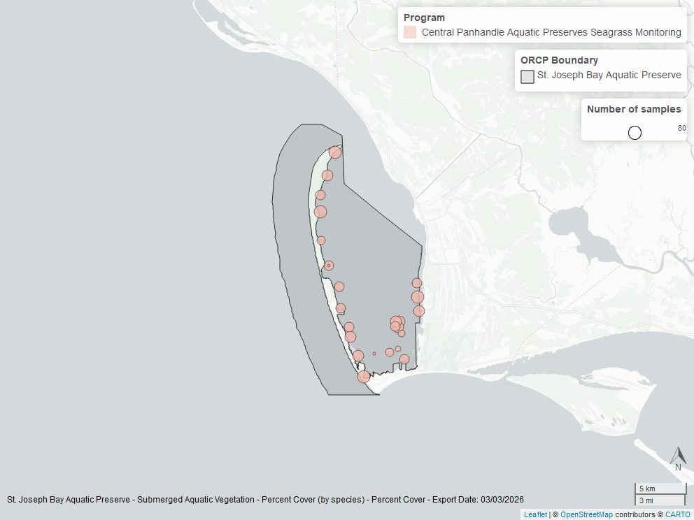

Map showing SAV sampling sites within the boundaries of *St. Joseph Bay Aquatic Preserve*. The point size reflects the number of samples at a given sampling site.

Program Information for Submerged Aquatic Vegetation

| ProgramID | N-Data | YearMin | YearMax | method | Sample Locations |
| --- | --- | --- | --- | --- | --- |
| 557 | 1272 | 2005 | 2023 | Braun Blanquet | 25 |

**Program names:**

*557* - Central Panhandle Aquatic Preserves Seagrass Monitoring<sup>10</sup>

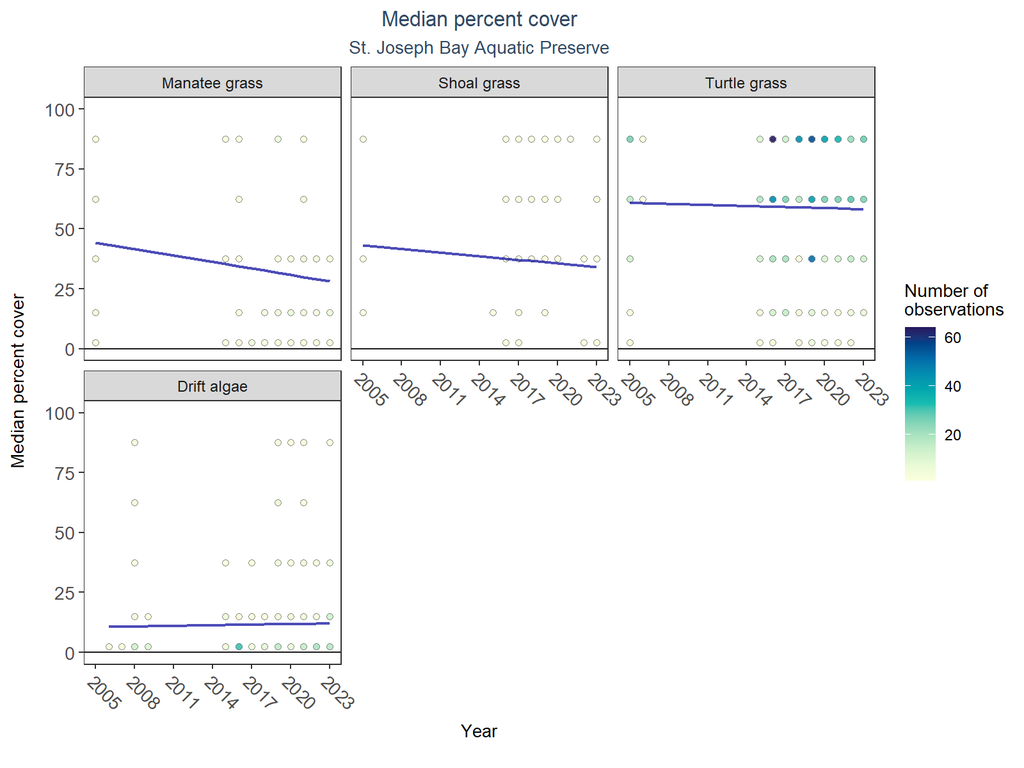

Scatter plots of median percent cover of submerged aquatic vegetation over time by group. Plots for time series that included five or more years of observations show the estimated trend as a blue line.

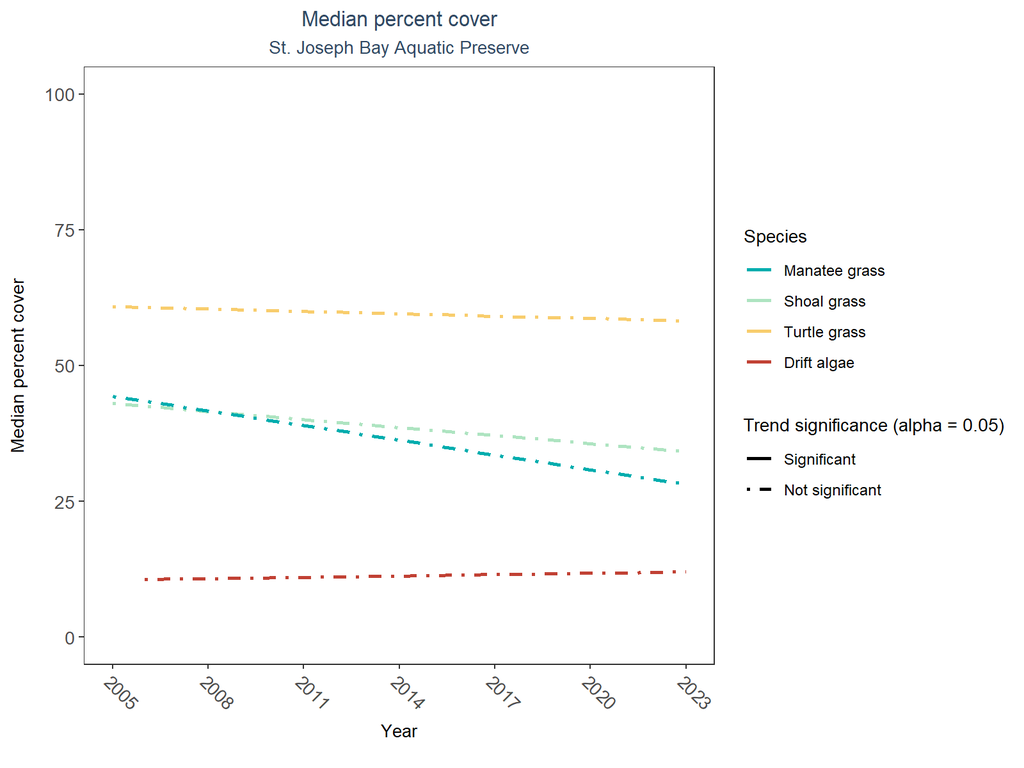

Trend lines of median percent cover of submerged aquatic vegetation over time for species that had five or more years of observations. Line type represents significance (solid) or non-significance (dashed) of the trends.

Percent Cover Trend Analysis for St. Joseph Bay Aquatic Preserve

| Species | Statistical Trend | Period of Record | LME Intercept | LME Slope | P |
| --- | --- | --- | --- | --- | --- |
| Drift algae | No detectable trend | 2006 - 2023 | 9.612037 | 0.0838013 | 0.8313898 |
| Shoal grass | No detectable trend | 2005 - 2023 | 48.448323 | -0.4914521 | 0.5032213 |
| Manatee grass | No detectable trend | 2005 - 2023 | 54.197170 | -0.8985878 | 0.2566989 |
| Turtle grass | No detectable trend | 2005 - 2023 | 62.380368 | -0.1420931 | 0.6874762 |

Manatee grass, shoal grass, turtle grass, and drift algae showed no detectable change in percent cover.

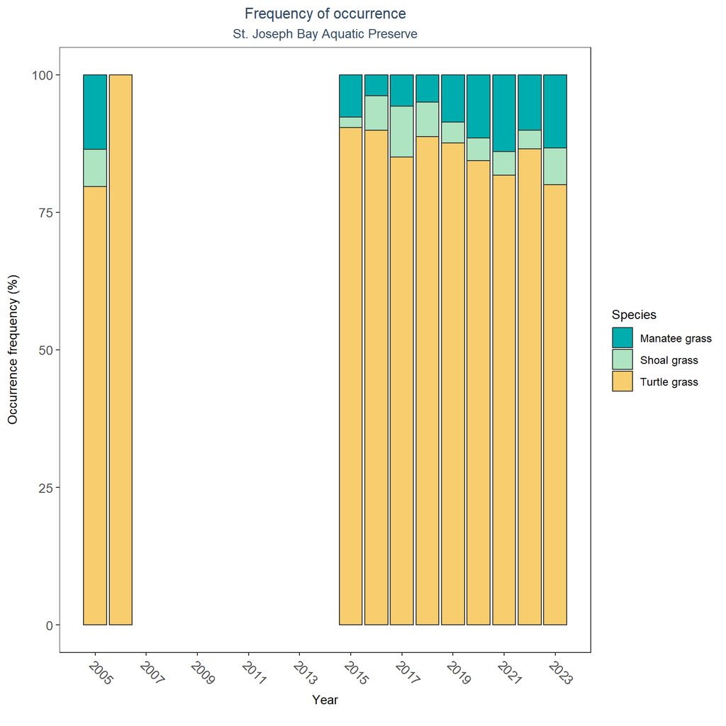

Bar plot of submerged aquatic vegetation species occurrence frequency over time by group.

## SAV Water Column Analysis

The following parameters are available for St. Joseph Bay Aquatic Preserve within the SAV_WC_Report:

- Colored Disolved Organic Matter
- Chlorophyll a
- Dissolved Oxygen
- Dissolved Oxygen Saturation
- pH
- Salinity
- Secchi Depth
- Water Temperature
- Total Nitrogen
- Turbidity

Access the reports here: DRAFT_SAV_WC_Report.pdf

# Species list

[output not shown]

1 - Submerged Aquatic Vegetation

# References

1.

University of Florida (UF); Institute of Food and Agricultural Sciences. [Florida LAKEWATCH Program](https://data.florida-seacar.org/programs/details/514). (2024).

2.

Florida Department of Environmental Protection (DEP); Office of Resilience and Coastal Protection (RCP); Central Panhandle Aquatic Preserves. [St. Andrews Aquatic Preserve Water Quality Monitoring](https://data.florida-seacar.org/programs/details/470). (2024).

3.

Florida Department of Environmental Protection (DEP). [Florida STORET / WIN](https://data.florida-seacar.org/programs/details/5002). (2024).

4.

Florida Department of Agriculture and Consumer Services (FDACS) - Division of Aquaculture. [Shellfish Harvest Area Classification Program](https://data.florida-seacar.org/programs/details/540). (2022).

5.

U.S. Environmental Protection Agency (EPA). [EPA STOrage and RETrieval Data Warehouse (STORET)/WQX](https://data.florida-seacar.org/programs/details/103). (2023).

6.

U.S. Environmental Protection Agency (EPA); Office of Research and Development. [Environmental Monitoring Assessment Program](https://data.florida-seacar.org/programs/details/115). (2004).

7.

U.S. Environmental Protection Agency (EPA); Office of Water; National Oceanic and Atmospheric Administration (NOAA); U.S. Geological Survey (USGS); U.S. Fish and Wildlife Service (USFWS); National Estuary Program (NEP); coastal states. [National Aquatic Resource Surveys, National Coastal Condition Assessment](https://data.florida-seacar.org/programs/details/118). (2021).

8.

Florida Fish and Wildlife Conservation Commission (FWC); Florida Fish and Wildlife Research Institute (FWRI). [Harmful Algal Bloom Marine Observation Network](https://data.florida-seacar.org/programs/details/95). (2018).

9.

Florida Department of Environmental Protection (DEP); Office of Resilience and Coastal Protection (RCP); Central Panhandle Aquatic Preserves. [Central Panhandle Aquatic Preserve WQ Monitoring](https://data.florida-seacar.org/programs/details/469) . (2024).

10.

Florida Department of Environmental Protection (DEP); Office of Resilience and Coastal Protection (RCP); Central Panhandle Aquatic Preserves. [Central Panhandle Aquatic Preserves Seagrass Monitoring](https://data.florida-seacar.org/programs/details/557). (2023).

11.

Florida Fish and Wildlife Conservation Commission (FWC). [Fisheries-Independent Monitoring (FIM) Program](https://data.florida-seacar.org/programs/details/69). (2022).

12.

Gulf States Marine Fisheries Commission. [Southeast Area Monitoring and Assessment Program (SEAMAP) - Gulf of Mexico Fall & Summer Shrimp/Groundfish Survey](https://data.florida-seacar.org/programs/details/60). (2016).

13.

Florida Department of Environmental Protection (DEP); Office of Resilience and Coastal Protection (RCP); Central Panhandle Aquatic Preserves. [Central Panhandle Aquatic Preserves Continuous Water Quality Monitoring](https://data.florida-seacar.org/programs/details/468). (2024).